# Advanced Statstical Concepts in R

Laurie Stevison

# Getting Started

*If you are using this code with the video, note that some slides have been added post-recording and are not shown. See walkthrough2.R in the compressed data tarball for the code from the recording.*

For this tutorial we will be working with the “Lab6_Perl_v_Awk.csv” “BodyFat.csv” datasets.

Make an R Notebook for this walk-through tutorial to save all the code you will be learning. We will cover:

- Practice reading in datasets with more complexity
- Making boxplots of factor data
- Subsetting data in different ways
- Fitting data to statistical models
  - `aov`
  - `glm`

# Set up workspace

- You are working within an R project (check in the top right corner of RStudio - you should see the project name “R_Mini_Course”).
- This means that the project directory will also be set as working directory. The exception is in a R Notebook, where the working directory is where the R Notebook is saved.
- You should be saving your notebooks in the R Project and using `../..` to point at the main project directory.
- Before starting, it may be helpful to have a chunk of code that does the following:
  - clear your workspace `rm(list=ls())`
  - load your packages `library(<package-name>)`
  - check your session information `sessionInfo()`
  - list files in your working directory `list.files(getwd())`

# Read in datasets

Our first dataset will be a summary of results from Lab #6: A comparisons of awk and perl.

You will need to add path information to the `raw_data` directory once you have uncompressed the data tarball.

Read “Lab6_Perl_v_Awk.csv” into an object called `pva`:

```r
#pva=read.csv(file="Lab6_Perl_v_Awk.csv")
#View(pva)
```

Read “BodyFat.csv” into an object called `fat`:

```r
#fat=read.csv(file="BodyFat.csv")
```

You may also read in the previously made object:

```r
pva <- readRDS(file = "../../data/Perl_v_Awk.rds")
head(pva, 3)
```

```
##   ID     Start.time Completion.time Operating.System...i.e..iOS..Ubuntu.
## 1  2 10/19/20 16:05  10/19/20 16:29                                  IOS
## 2  3 10/19/20 17:56  10/19/20 17:58                               Mac OS
## 3  4 10/19/20 17:58  10/19/20 17:58                               Mac OS
##   Programming.Language. Sys.Run.Time. Input.VCF.File.Size.
## 1                   Awk            na                 Full
## 2                  Perl         0.031                 Full
## 3                   Awk          0.03                 Full
```

```r
fat <- readRDS(file = "../../data/BodyFat.rds")
head(fat, 3)
```

```
##   IDNO BODYFAT DENSITY AGE WEIGHT HEIGHT ADIPOSITY NECK CHEST ABDOMEN  HIP
## 1    1    12.6  1.0708  23 154.25  67.75      23.7 36.2  93.1    85.2 94.5
## 2    2     6.9  1.0853  22 173.25  72.25      23.4 38.5  93.6    83.0 98.7
## 3    3    24.6  1.0414  22 154.00  66.25      24.7 34.0  95.8    87.9 99.2
##   THIGH KNEE ANKLE BICEPS FOREARM WRIST  X
## 1  59.0 37.3  21.9   32.0    27.4  17.1 NA
## 2  58.7 37.3  23.4   30.5    28.9  18.2 NA
## 3  59.6 38.9  24.0   28.8    25.2  16.6 NA
```

Click the data object in the environment tab in RStudio…

Notice these five columns of data:

- `ID` (Student)
- `Sys.Run.Time.` (Run Time)
- `Programming.Language.` (e.g. Perl; Awk)
- `Input.VCF.File.Size` (Partial/Full File)
- `Operating.System...i.e..iOS..Ubuntu.` (OS)

We also have some missing data.

# Compare runtime of Perl versus Awk

Let’s compare the distribution of run times for each language.

```r
#plot(pva$Programming.Language.,pva$Sys.Run.Time.)
```

Notice, the plot looks unexpected or it did not plot at all. That is because we have some missing data and columns that have not been coded correctly.

If you are reading in the raw data, we can read the data in again - specifying that the string “na” should be coded as missing data and columns with strings should be treated as factors (this means that these columns can be summarized into categories or levels).

```r
#pva=read.csv(file="Lab6_Perl_v_Awk.csv",na.strings="na",stringsAsFactors = T)
```

### Extra `dplyr` Practice

If you are reading in the saved data object in the beginning, let’s get some extra practice with dplyr to perform these same modifications, step-by-step.

```r
pva <- dplyr::na_if(pva, "na")
head(pva, 3)
```

```
##   ID     Start.time Completion.time Operating.System...i.e..iOS..Ubuntu.
## 1  2 10/19/20 16:05  10/19/20 16:29                                  IOS
## 2  3 10/19/20 17:56  10/19/20 17:58                               Mac OS
## 3  4 10/19/20 17:58  10/19/20 17:58                               Mac OS
##   Programming.Language. Sys.Run.Time. Input.VCF.File.Size.
## 1                   Awk          <NA>                 Full
## 2                  Perl         0.031                 Full
## 3                   Awk          0.03                 Full
```

Notice the “na” strings are now properly coded as NAs (compare with slide 5). If you run summary on the object, we still have the issue of `Sys.Run.Time.` being coded as “character” data.

Let’s see how we can fix that on the next slide…

```r
pva$Sys.Run.Time. <- as.numeric(pva$Sys.Run.Time.)
summary(pva)
```

```
##        ID      Start.time        Completion.time
##  Min.   : 2   Length:37          Length:37
##  1st Qu.:11   Class :character   Class :character
##  Median :20   Mode  :character   Mode  :character
##  Mean   :20
##  3rd Qu.:29
##  Max.   :38
##
##  Operating.System...i.e..iOS..Ubuntu. Programming.Language. Sys.Run.Time.
##  Length:37                            Length:37             Min.   :  0.0000
##  Class :character                     Class :character      1st Qu.:  0.0160
##  Mode  :character                     Mode  :character      Median :  0.0490
##                                                             Mean   : 14.0506
##                                                             3rd Qu.:  0.1205
##                                                             Max.   :426.0000
##                                                             NA's   :6
##  Input.VCF.File.Size.
##  Length:37
##  Class :character
##  Mode  :character
##
##
##
##
```

Fixed! Lastly, we want to make sure the other columns are treated as categorical.

Here, we are specifying two columns to be treated as categorical (i.e., mutate the data across `Programming.Language.` & `Input.VCF.File.Size.` by coding them factors).

Remember the `%>%` symbol from magrittr (tidyverse) is a [pipe](https://towardsdatascience.com/an-introduction-to-the-pipe-in-r-823090760d64).

```r
pva <- pva %>% dplyr::mutate(across(c(Programming.Language., Input.VCF.File.Size.), as.factor))
```

Use `summary` to see the changes made to the two columns of data we converted to factors.

We could convert all “character” columns to factors by replacing

`...across(c(<columns>, <targeted>),...`

with

`...across(where(is.character),...`

Let’s try the plot again:

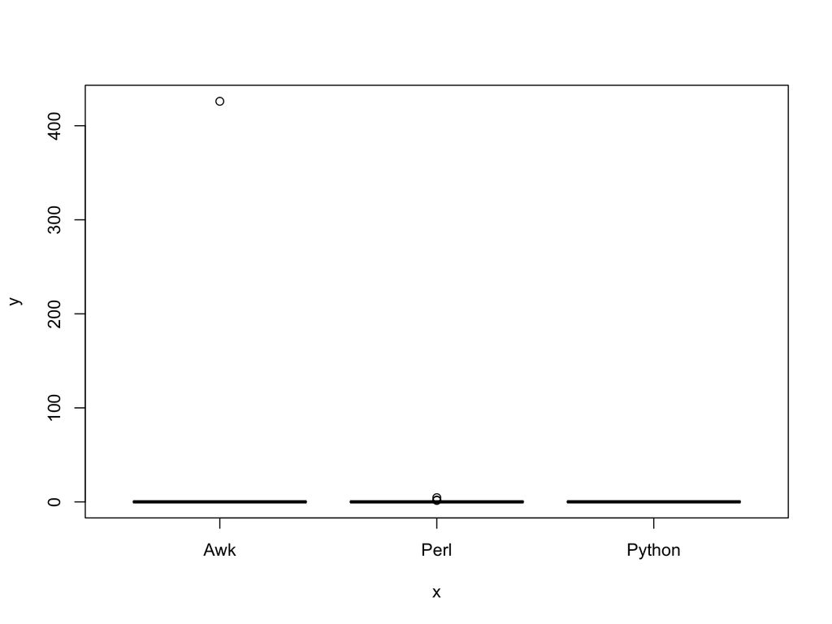

```r
pva$Programming.Language. <- as.factor(pva$Programming.Language.)
plot(pva$Programming.Language.,pva$Sys.Run.Time.)
```

Now, we have a box plot of each dataset.

What modification could you make to better visualize this plot?

# Basic Summary Statistics

Let’s revisit some basic summary statistics for this dataset.

```r
summary(pva)
```

```
##        ID      Start.time        Completion.time
##  Min.   : 2   Length:37          Length:37
##  1st Qu.:11   Class :character   Class :character
##  Median :20   Mode  :character   Mode  :character
##  Mean   :20
##  3rd Qu.:29
##  Max.   :38
##
##  Operating.System...i.e..iOS..Ubuntu. Programming.Language. Sys.Run.Time.
##  Length:37                            Awk   :13             Min.   :  0.0000
##  Class :character                     Perl  :18             1st Qu.:  0.0160
##  Mode  :character                     Python: 6             Median :  0.0490
##                                                             Mean   : 14.0506
##                                                             3rd Qu.:  0.1205
##                                                             Max.   :426.0000
##                                                             NA's   :6
##  Input.VCF.File.Size.
##  Full   :22
##  Partial:15
##
##
##
##
##
```

Notice the range for mean run time is quite skewed. Let’s look at the overall distribution

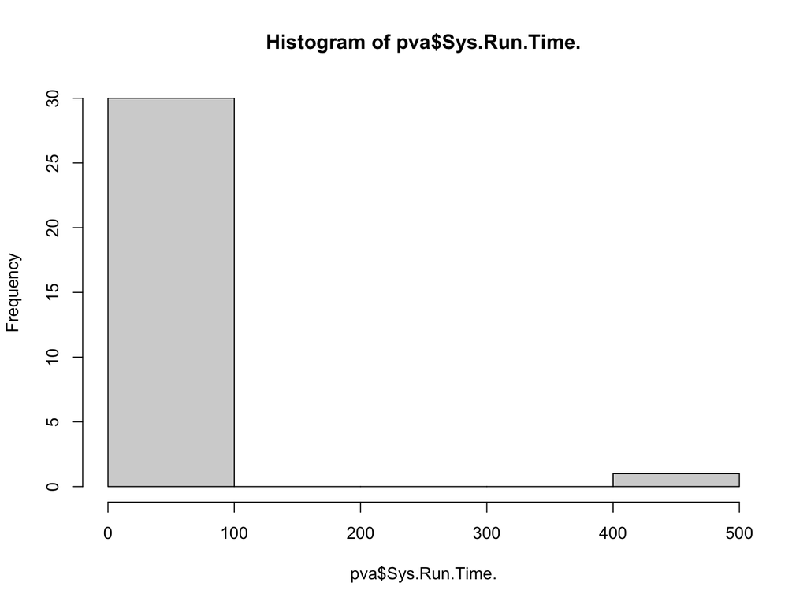

```r
hist(pva$Sys.Run.Time.)
```

# Remove outliers

Because the majority of our observations are less than 1 and some folks may have put actual run time instead of SysRunTime, let’s go ahead and exclude these extreme values and look at the boxplot again:

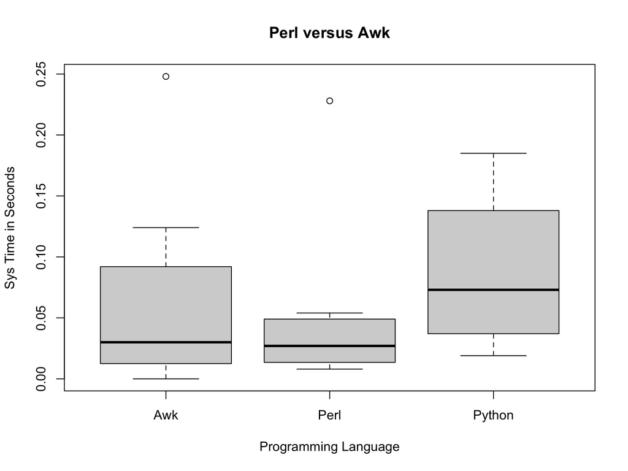

```r
pva2=subset(pva,pva$Sys.Run.Time.<=1)
plot(pva2$Programming.Language.,pva2$Sys.Run.Time.,main="Perl versus Awk",xlab="Programming Language",ylab="Sys Time in Seconds")
```

Now we can see the boxes a bit better and while we still have outliers, we’ve mostly removed the extremes.

# Examine mean in each group

From the boxplots, it looks like Awk is a bit slower than Perl, but let’s compare the means of each group:

```r
mean(pva2$Sys.Run.Time.[pva2$Programming.Language.=="Perl"])
```

```
## [1] 0.04375
```

```r
mean(pva2$Sys.Run.Time.[pva2$Programming.Language.=="Awk"])
```

```
## [1] 0.06309091
```

Notice this new way of subsetting from categorical data.

# But didn’t we do large and small file sizes? We should look at this a bit closer.

First, let’s look at the full size file results:

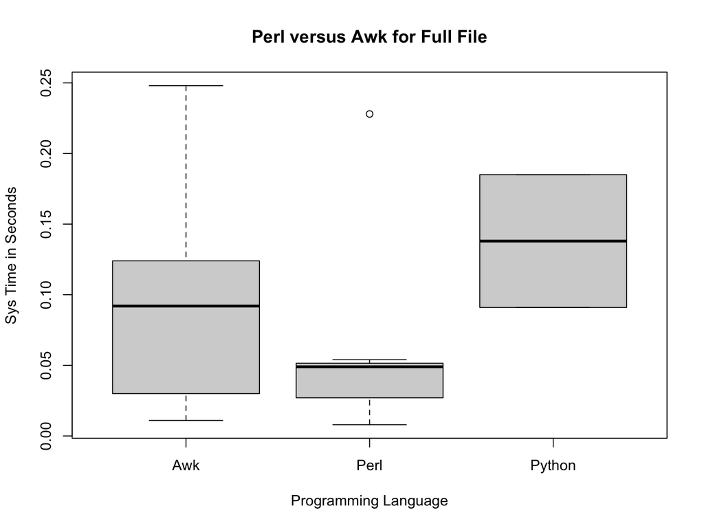

```r
full=subset(pva2,pva2$Input.VCF.File.Size.=="Full")
plot(full$Programming.Language.,full$Sys.Run.Time.,main="Perl versus Awk for Full File",xlab="Programming Language",ylab="Sys Time in Seconds")
```

Here, Perl appears faster than Awk, with Python the slowest. But what about for the smaller file when you used `head` to get only the first 10,000 lines?

# Smaller file size comparison

Now, let’s look at the small size fill results:

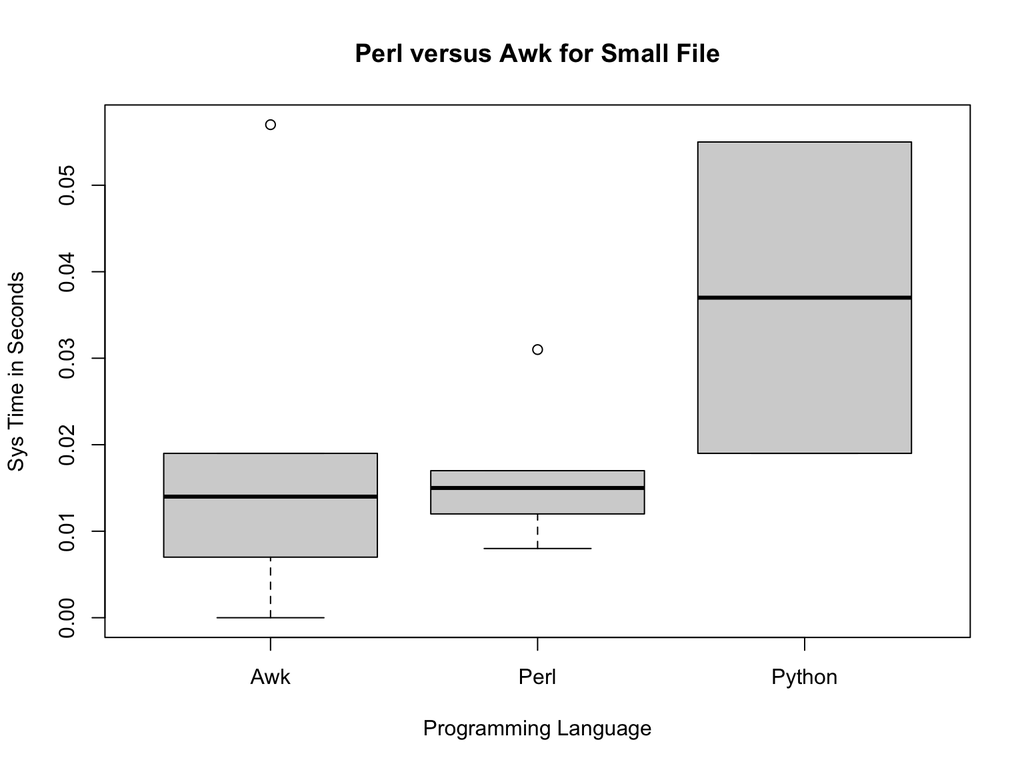

```r
small=subset(pva2,pva2$Input.VCF.File.Size.=="Partial")
plot(small$Programming.Language.,small$Sys.Run.Time.,main="Perl versus Awk for Small File",xlab="Programming Language",ylab="Sys Time in Seconds")
```

Now, Perl and Awk are pretty similar to each other and python is still the slowest.

# Again, let’s look at the mean values:

```r
#full file size
mean(full$Sys.Run.Time.[full$Programming.Language.=="Perl"])
```

```
## [1] 0.06314286
```

```r
mean(full$Sys.Run.Time.[full$Programming.Language.=="Awk"])
```

```
## [1] 0.0995
```

```r
#short file size
mean(small$Sys.Run.Time.[small$Programming.Language.=="Perl"])
```

```
## [1] 0.0166
```

```r
mean(small$Sys.Run.Time.[small$Programming.Language.=="Awk"])
```

```
## [1] 0.0194
```

So, the means are different, but are they statistically different?

# Is this a statistical difference?

We can test this by using the function `aov` which fits the data to an analysis of variance model. This calls the `lm` function, which is for linear models.

```r
model_full=aov(full$Sys.Run.Time.~full$Programming.Language.)
model_small=aov(small$Sys.Run.Time.~small$Programming.Language.)

#get AOV Table
summary(model_full)
```

```
##                            Df  Sum Sq  Mean Sq F value Pr(>F)
## full$Programming.Language.  2 0.01012 0.005058   0.815  0.466
## Residuals                  12 0.07444 0.006204
```

```r
summary(model_small)
```

```
##                             Df    Sum Sq   Mean Sq F value Pr(>F)
## small$Programming.Language.  2 0.0006213 0.0003106   0.955   0.42
## Residuals                    9 0.0029264 0.0003252
```

Answer: NO! So, don’t do anything rash, like choose a particular language based on these data!

*On your own*: We also recorded OS in this dataset. On your own, compare the sys run time based on OS just like we did here using Programming Language. If you chose to read in the pre-existing object, remember to revisit the code we used to correctly code our categorical columns.

# Now, let’s return to the “BodyFat.csv” dataset

Basic Summary Statistics:

As we did before, let’s revisit some basic summaries of this dataset.

```r
#statistical summary of data
summary(fat)
```

```
##       IDNO           BODYFAT         DENSITY           AGE
##  Min.   :  1.00   Min.   : 0.00   Min.   :0.995   Min.   :22.00
##  1st Qu.: 63.75   1st Qu.:12.80   1st Qu.:1.041   1st Qu.:35.75
##  Median :126.50   Median :19.00   Median :1.055   Median :43.00
##  Mean   :126.50   Mean   :18.94   Mean   :1.056   Mean   :44.88
##  3rd Qu.:189.25   3rd Qu.:24.60   3rd Qu.:1.070   3rd Qu.:54.00
##  Max.   :252.00   Max.   :45.10   Max.   :1.109   Max.   :81.00
##      WEIGHT          HEIGHT        ADIPOSITY          NECK
##  Min.   :118.5   Min.   :29.50   Min.   :18.10   Min.   :31.10
##  1st Qu.:159.0   1st Qu.:68.25   1st Qu.:23.10   1st Qu.:36.40
##  Median :176.5   Median :70.00   Median :25.05   Median :38.00
##  Mean   :178.9   Mean   :70.15   Mean   :25.44   Mean   :37.99
##  3rd Qu.:197.0   3rd Qu.:72.25   3rd Qu.:27.32   3rd Qu.:39.42
##  Max.   :363.1   Max.   :77.75   Max.   :48.90   Max.   :51.20
##      CHEST           ABDOMEN            HIP            THIGH
##  Min.   : 79.30   Min.   : 69.40   Min.   : 85.0   Min.   :47.20
##  1st Qu.: 94.35   1st Qu.: 84.58   1st Qu.: 95.5   1st Qu.:56.00
##  Median : 99.65   Median : 90.95   Median : 99.3   Median :59.00
##  Mean   :100.82   Mean   : 92.56   Mean   : 99.9   Mean   :59.41
##  3rd Qu.:105.38   3rd Qu.: 99.33   3rd Qu.:103.5   3rd Qu.:62.35
##  Max.   :136.20   Max.   :148.10   Max.   :147.7   Max.   :87.30
##       KNEE           ANKLE          BICEPS         FOREARM          WRIST
##  Min.   :33.00   Min.   :19.1   Min.   :24.80   Min.   :21.00   Min.   :15.80
##  1st Qu.:36.98   1st Qu.:22.0   1st Qu.:30.20   1st Qu.:27.30   1st Qu.:17.60
##  Median :38.50   Median :22.8   Median :32.05   Median :28.70   Median :18.30
##  Mean   :38.59   Mean   :23.1   Mean   :32.27   Mean   :28.66   Mean   :18.23
##  3rd Qu.:39.92   3rd Qu.:24.0   3rd Qu.:34.33   3rd Qu.:30.00   3rd Qu.:18.80
##  Max.   :49.10   Max.   :33.9   Max.   :45.00   Max.   :34.90   Max.   :21.40
##     X
##  Mode:logical
##  NA's:252
##
##
##
##
```

```r
range(fat$WEIGHT)
```

```
## [1] 118.50 363.15
```

```r
range(fat$BODYFAT)
```

```
## [1]  0.0 45.1
```

Summary is a much more comprehensive view of this dataset.

# Analyzing a complex dataset

In a previous video, you were asked to analyze this dataset on your own. Each of you did independent correlations of each variable and how it correlated with bodyfat. Because these were non-independent tests, we have to correct for multiple testing. However, a better way to compare how different parameters predict a response variable is to fit the data to a more complex model

```r
#first, like aov, we will fit a generalized linear model:
fit=glm(BODYFAT~WEIGHT+DENSITY+ADIPOSITY+AGE+HEIGHT+NECK+CHEST+ABDOMEN+HIP+THIGH+KNEE+ANKLE+BICEPS+FOREARM+WRIST,data=fat)

#to see the fit, we will make a summary table
summary(fit)
```

```
##
## Call:
## glm(formula = BODYFAT ~ WEIGHT + DENSITY + ADIPOSITY + AGE +
##     HEIGHT + NECK + CHEST + ABDOMEN + HIP + THIGH + KNEE + ANKLE +
##     BICEPS + FOREARM + WRIST, data = fat)
##
## Deviance Residuals:
##     Min       1Q   Median       3Q      Max
## -7.7632  -0.3308  -0.0954   0.2078  13.9487
##
## Coefficients:
##               Estimate Std. Error t value Pr(>|t|)
## (Intercept)  4.190e+02  9.802e+00  42.750   <2e-16 ***
## WEIGHT       1.197e-02  1.467e-02   0.816    0.415
## DENSITY     -3.816e+02  7.559e+00 -50.481   <2e-16 ***
## ADIPOSITY   -5.493e-02  8.113e-02  -0.677    0.499
## AGE          1.078e-02  8.808e-03   1.224    0.222
## HEIGHT      -1.782e-02  3.019e-02  -0.590    0.556
## NECK        -2.062e-02  6.427e-02  -0.321    0.749
## CHEST        2.993e-02  2.856e-02   1.048    0.296
## ABDOMEN      2.260e-02  3.016e-02   0.749    0.454
## HIP          1.611e-02  4.023e-02   0.401    0.689
## THIGH        1.354e-03  3.980e-02   0.034    0.973
## KNEE        -3.978e-02  6.705e-02  -0.593    0.554
## ANKLE       -7.170e-02  6.073e-02  -1.181    0.239
## BICEPS      -6.291e-02  4.688e-02  -1.342    0.181
## FOREARM      4.324e-02  5.447e-02   0.794    0.428
## WRIST        3.640e-02  1.480e-01   0.246    0.806
## ---
## Signif. codes:  0 '***' 0.001 '**' 0.01 '*' 0.05 '.' 0.1 ' ' 1
##
## (Dispersion parameter for gaussian family taken to be 1.359181)
##
##     Null deviance: 15079.02  on 251  degrees of freedom
## Residual deviance:   320.77  on 236  degrees of freedom
## AIC: 809.95
##
## Number of Fisher Scoring iterations: 2
```

Here, we have built a statsitical model to show how body fat varies due to MULTIPLE parameters in the data.

We will return to this dataset once more in Module 5 to graphically explore the relationship between Density and Body Fat.